# Exploratory Data Analysis 2 en 3

Deze lesopdracht sluit aan op de volgende datacamp chapters:

- Exploratory Data Analysis 2: https://campus.datacamp.com/courses/exploratory-data-analysis-in-python/data-cleaning-and-imputation?ex=1
- Exploratory Data Analysis 3: https://campus.datacamp.com/courses/exploratory-data-analysis-in-python/relationships-in-data?ex=1 (Alleen het deel over tijdspatronen)

We gaan verder met de dataset van de vorige les.Dit is een dataset met klantgegevens. De kolommen zijn

- Geboortejaar
- Opleidingsniveau
- Burgelijke staat
- Inkomen
- Aantal kinderen in huis
- Aantal tieners in huis
- Datum waarop een klant voor het eerst klant is geworden
- Aantal dagen sinds laatste aankoop
- Hoeveelheid geld uitgegeven aan wijn in de laatste 2 jaar
- Hoeveelheid geld uitgegeven aan fruit de afgelopen 2 jaar
- Hoeveelheid geld uitgegeven aan vlees de afgelopen 2 jaar
- Hoeveelheid geld uitgegeven aan vis de afgelopen 2 jaar
- Hoeveelheid geld uitgegeven aan snoep de afgelopen 2 jaar
- Hoeveelheid geld uitgegeven aan goud de afgelopen 2 jaar
- Indicator of de persoon de laatste keer mee deed aan een actie.

Machine Learning modellen proberen zaken te voorspellen. Het uiteindelijke doel van deze dataset is voorspellen of klanten gebruik zullen maken van een actie.

Voordat we machine learning toepassen voeren we altijd eerst een Exploratory Data Analysis (EDA) uit.In de vorige les hebben we gekeken naar de verdelingen van de kolommen in de dataset. We hebben dit nodig voor de onderwerpen van deze opdracht.

- Voer onderstaande cel uit om het dataframe data aan te maken.

```python
import pandas as pd
import numpy as np
import seaborn as sns
import matplotlib.pyplot as plt
data = pd.read_excel('shopping.xlsx')
```

### 1 Verdelingen en missende waardes

We hebben nu gezien hoe je inzicht kunt krijgen in de verdeling van data. Dit heb je onder andere nodig bij het vullen van "missende waardes" of bij het bepalen van "outliers".

- Toon een overzicht met het aantal missende waardes per kolom.
- Waarom kunnen missende waardes een probleem vormen?
- Toon een histogram van de kolom(men) met missende waardes.
- Toon de verdeling, mediaan en gemiddelde van de kolom(men) met missende waardes.
- Wat is het meest geschikt om de missende waardes mee te vullen? Leg uit waarom.
- Gebruik fillna() om de nieuwe kolom "Income_filled" aan te maken waarin de missende waardes zijn gevuld met de door jou gekozen waarde.
- Toon een grafiek met de histogrammen van 'Income' en 'Income_filled'. Hoe zie je het resultaat van het vullen terug in deze grafiek?

```
Year_Birth                 0
Education                  0
Marital_Status             0
Income                    24
Kidhome                    0
Teenhome                   0
Date_becoming_Customer     0
Recency                    0
MntWines                   0
MntFruits                  0
MntMeatProducts            0
MntFishProducts            0
MntSweetProducts           0
MntGoldProds               0
Responded to deal          0
dtype: int64
```

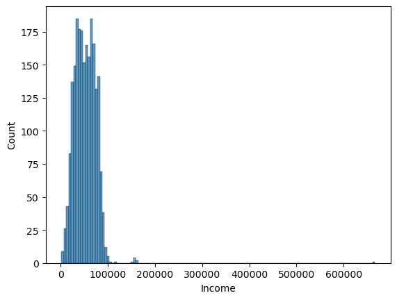

```
mean 52247.25135379061
median 51381.5
```

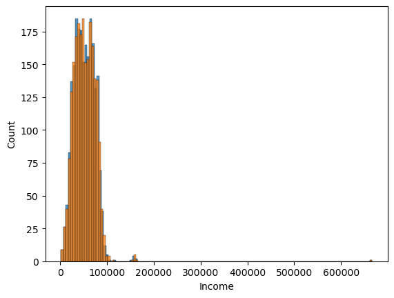

```python
display(data.isna().sum())
# Problemen missende waardes:
    # affects distributions --> less representative of the population
    # (als bijv. missende waardes uit dezelfde categorie komen) --> can result in drawing incorrect conclusions.
sns.histplot(data['Income'])
plt.show()
print('mean', data['Income'].mean())
print('median', data['Income'].median())
#door outliers is het gemiddelde hoger. Dit maakt het geschikt dan de mediaan om mee te vullen.
data['Income_filled'] = data['Income'].fillna(data['Income'].median())
sns.histplot(data['Income'])
sns.histplot(data['Income_filled'])
#De hoogste oranje piek in het midden is het resultaat van van het vullen.
plt.show()
```

### 2 Missende waardes vullen per groep

- Maak twee grafieken (**Tip**: zorg ervoor dat de x-as met 'income' voor beide grafieken tot 200000 gaat):
  - Een barchart met het gemiddelde inkomen per opleidingsniveau.
  - Een boxplot voor het inkomen per opleidingsniveau
- Wat valt je op?

Het is mogelijk om missende waardes te vullen met verschillende getallen. Dus niet met de mediaan of het gemiddelde van de kolom. In plaats daarvan kun je ook werken met een "groepsmediaan" of "groepsgemiddelde".

- Gebruik fillna() om de nieuwe kolom "Income_filled_2" aan te maken waarin de missende waardes zijn gevuld met een groepsgemiddelde of groepsmediaan. Bepaal zelf wat het beste is. Zie voor tips: https://stackoverflow.com/questions/19966018/filling-missing-values-by-mean-in-each-group
- Toon een grafiek met de histogrammen van 'Income' en 'Income_filled' en 'Income_filled_2'. Hoe zie je het resultaat vam het vullen terug in deze grafiek?

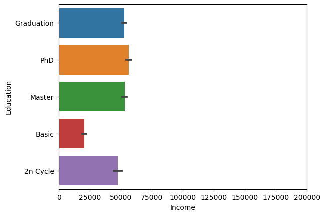

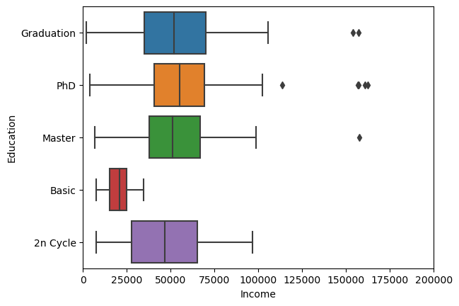

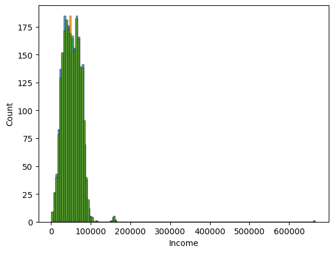

```python
sns.barplot(data=data, x='Income', y='Education')
plt.xlim(0, 200000)
plt.show()

sns.boxplot(data=data, x='Income', y='Education')
plt.xlim(0, 200000)
plt.show()

# Mensen met hoger opleidingsniveau lijken een (iets) hoger inkomen te hebben.

data['Income_filled_2'] = data['Income'].fillna(data.groupby('Education')['Income'].transform('median'))
data['Income_filled_2'].isna().sum()

sns.histplot(data['Income'])
sns.histplot(data['Income_filled'])
sns.histplot(data['Income_filled_2'])
plt.show()
# de oranje piek is nu verdeeld over meerdere pieken in de groene grafiek.Benadert de oorspronkelijke verdeling beter.
```

### 3 Converteren en analyseren van categorieen

- Maak een grafiek waarmee je laat zien of 'Marital_Status' invloed heeft op het al dan niet ingaan op een actie ('Responded to deal'). Als het goed is heb je ontdekt dat er veel categorieen zijn in de 'Marital_Status' kolom. Hierdoor zegt de visualisatie van de vorige vraag weinig.
- Breng het aantal categorieen terug naar een kleiner aantal logische categorieen.
- Maak nogmaals, met de nieuwe categorieen, een grafiek waarmee je laat zien of 'Marital_Status' invloed heeft op het al dan niet ingaan op een actie ('Responded to deal').
- Wat maak je op uit deze nieuwe grafiek?

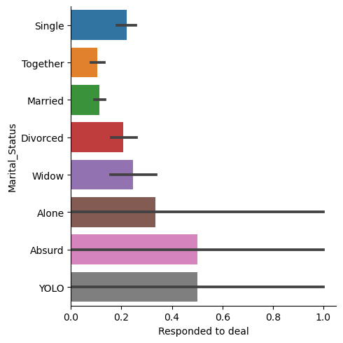

```
Single
False    1444
True      792
Other       4
Name: count, dtype: int64
```

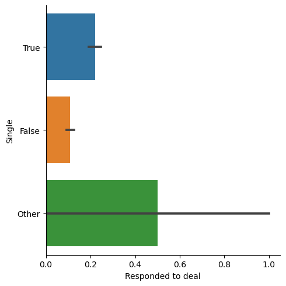

```python
sns.catplot(data, x='Responded to deal', y='Marital_Status', kind='bar')
plt.show()

status = [True, False]
data['Marital_Status'].value_counts()
single = "Sing|Divorced|Widow|Alon" #Niet hele string is nodig (zie Sing)
partner = "Married|Together"
conditions = [
    (data['Marital_Status'].str.contains(single)),
    (data['Marital_Status'].str.contains(partner))
]

data['Single'] = np.select(conditions, status, default='Other')
display(data['Single'].value_counts())

sns.catplot(data, x='Responded to deal', y='Single', kind='bar')
plt.show()
#Singles zijn meer geneigd om op een actie in te gaan.
```

### 4 Toevoegen van statistieken aan een dataframe

Het kan nuttig zijn om bepaalde groepstatistieken berekend voor het hele dataframe ook in de regels van het dataframe te zetten.

- Voeg de kolom 'mean_income_by_education' toe aan data waarin je het gemiddelde inkomen van het betreffende opleidingsniveau ('Education') toont.
- Laat zien hoe vaak ieder gemiddeld inkomensniveau wordt getoond.

```python
data['mean_income_by_education'] = data.groupby('Education')['Income'].transform('mean')
data['mean_income_by_education2'] = data.groupby('Education')['Income'].transform(np.mean)
data['mean_income_by_education3'] = data.groupby('Education')['Income'].transform(lambda x: x.mean()) # volgens datacamp,
#lambda kennen ze nog (net) niet en is ook helemaal niet nodig.
display(data['Education'].value_counts())
display(data['mean_income_by_education'].value_counts())
display(data['mean_income_by_education2'].value_counts())
data['mean_income_by_education3'].value_counts()
```

```
Education
Graduation    1127
PhD            486
Master         370
2n Cycle       203
Basic           54
Name: count, dtype: int64
```

```
mean_income_by_education
52720.373656    1127
56145.313929     486
52917.534247     370
47633.190000     203
20306.259259      54
Name: count, dtype: int64
```

```
mean_income_by_education2
52720.373656    1127
56145.313929     486
52917.534247     370
47633.190000     203
20306.259259      54
Name: count, dtype: int64
```

```
mean_income_by_education3
52720.373656    1127
56145.313929     486
52917.534247     370
47633.190000     203
20306.259259      54
Name: count, dtype: int64
```

### 5 Outliers verwijderen

We hebben in diverse boxplots gezien dat er outliers zijn. Sommige outliers kunnen worden verwijderd en sommige kunnen blijven bestaan.

- Bekijk de boxplots nogmaals. Van welke kolommen lijkt het zinvol om de outliers te verwijderen? Waarom?
- Toon de regels uit data waarbij in de gekozen kolommen outliers zijn die kunnen worden verwijderd. Kies hierbij voor iedere kolom een grenswaarde en leg uit waarom je voor die grenswaarde kiest.
- Verwijder de regels met outliers.

```python
# Year_Birth en Income: deze outliers lijken onwaarschijnlijk vanwege extreem hoge leeftijd of extreem hoog inkomen.
# en het gaat om kleine aantallen.
# Bij meer info zou je ook 19 kunnen vervangen door 20 en 18 door 19 bij year_birth

q25_yb = data['Year_Birth'].quantile(.25)
q75_yb = data['Year_Birth'].quantile(.75)
iqr_yb = q75_yb - q25_yb
#grenswaarde 1.5 omdat al deze mensen onwaarschijnlijk oud zijn.
lower_yb = q25_yb - 1.5 * iqr_yb
upper_yb = q75_yb + 1.5 * iqr_yb

outliers_yb = data[(data['Year_Birth']<lower_yb) | (data['Year_Birth']> upper_yb)]
display(outliers_yb)

q25_ic = data['Income'].quantile(.25)
q75_ic = data['Income'].quantile(.75)
iqr_ic = q75_ic - q25_ic
#grenswaarde 3 omdat bij 1.5 er regels zijn die nog steeds waarschijnlijk kloppen.
#je kunt overwegen om deze outliers niet te verwijderen. Zo'n hoog inkomen is mogelijk.
#vanwege mogelijke invloed op het model lijkt verwijderen verstandig.
lower_ic = q25_ic - 3 * iqr_ic
upper_ic = q75_ic + 3 * iqr_ic

outliers_ic = data[(data['Income']<lower_ic) | (data['Income']> upper_ic)]
display(outliers_ic)

#verwijderen via ~ doe je precies het omgekeerde, booleans worden verwisseld
outliers_removed = data[~(data['Year_Birth']<lower_yb) | (data['Year_Birth']> upper_yb)]
outliers_removed = data[~(data['Income']<lower_ic) | (data['Income']> upper_ic)]
```

|  | Year_Birth | Education | Marital_Status | Income | Kidhome | Teenhome | Date_becoming_Customer | Recency | MntWines | MntFruits | ... | MntFishProducts | MntSweetProducts | MntGoldProds | Responded to deal | Income_filled | Income_filled_2 | Single | mean_income_by_education | mean_income_by_education2 | mean_income_by_education3 |
| --- | --- | --- | --- | --- | --- | --- | --- | --- | --- | --- | --- | --- | --- | --- | --- | --- | --- | --- | --- | --- | --- |
| 192 | 1900 | 2n Cycle | Divorced | 36640.0 | 1 | 0 | 2013-09-26 | 99 | 15 | 6 | ... | 7 | 4 | 25 | 0 | 36640.0 | 36640.0 | True | 47633.190000 | 47633.190000 | 47633.190000 |
| 239 | 1893 | 2n Cycle | Single | 60182.0 | 0 | 1 | 2014-05-17 | 23 | 8 | 0 | ... | 7 | 0 | 2 | 0 | 60182.0 | 60182.0 | True | 47633.190000 | 47633.190000 | 47633.190000 |
| 339 | 1899 | PhD | Together | 83532.0 | 0 | 0 | 2013-09-26 | 36 | 755 | 144 | ... | 104 | 64 | 224 | 0 | 83532.0 | 83532.0 | False | 56145.313929 | 56145.313929 | 56145.313929 |

3 rows × 21 columns

|  | Year_Birth | Education | Marital_Status | Income | Kidhome | Teenhome | Date_becoming_Customer | Recency | MntWines | MntFruits | ... | MntFishProducts | MntSweetProducts | MntGoldProds | Responded to deal | Income_filled | Income_filled_2 | Single | mean_income_by_education | mean_income_by_education2 | mean_income_by_education3 |
| --- | --- | --- | --- | --- | --- | --- | --- | --- | --- | --- | --- | --- | --- | --- | --- | --- | --- | --- | --- | --- | --- |
| 2233 | 1977 | Graduation | Together | 666666.0 | 1 | 0 | 2013-06-02 | 23 | 9 | 14 | ... | 8 | 1 | 12 | 0 | 666666.0 | 666666.0 | False | 52720.373656 | 52720.373656 | 52720.373656 |

1 rows × 21 columns

# Tijdspatronen

We gaan nu verder met herkennen van tijdspatronen. We gebruiken daarvoor het dataframe df.

Onderstaande opdrachten zijn gebaseerd op het eerste deel van:

- Exploratory Data Analysis 3: https://campus.datacamp.com/courses/exploratory-data-analysis-in-python/relationships-in-data?ex=1 (Alleen het deel over tijdspatronen)

Het dataframe df heeft de volgende kolommen

- date_hour: Je hebt per **uur** informatie over de periode van 1-1-2011 t/m 30-11-2012
- holiday: Vakantiedag of geen vakantiedag
- weathersit: Weersituatie:
  1. Helder, licht bewolkt, deels bewolkt
  2. Mistig , mistig en licht bewolkt
  3. Lichte sneeuw, lichte regen, lichte regen en onweer, zwaar bewolkt, lichte regen en zwaar bewolkt
  4. Zware regen, hagel, zware mist, sneeuw.
- temp: genormaliseerde temperatuur
- atemp: genormaliseerde gevoelstemperatuur
- hum: genormaliseerde luchtvochtigheid
- windspeed: genormaliseerde windsnelheid.
- cnt: het aantal verhuurde fietsen

Deze dataset kan worden gebruikt om het aantal verhuurde fietsen per uur te voorspellen. Hierbij worden zowel tijdskenmerken gebruikt als andere kenmerken, zoals temperatuur.

- Voer onderstaande cel uit om de dataset te laden.

```python
df = pd.read_csv('train.csv')
```

### 6 datum en tijdsinstelling

- Bekijk de datatypes van de kolommen df. Welke kolom(men) heeft (hebben) nog niet de juiste datum- en tijdsinstellingen?
- Pas op 2 manieren het datatype hiervan aan naar het juiste type:
  - Op de manier zoals in Datacamp.
  - Door de dataset op een andere manier in te lezen via pd.read_csv().

```python
print('Voor:')
display(df.info()) #date_hour is object
df['date_hour'] = pd.to_datetime(df['date_hour']) # methode 1 (datacamp)
df = pd.read_csv('train.csv', parse_dates=['date_hour']) # methode 2

print('Na:')
display(df.info())
```

```
Voor:
<class 'pandas.core.frame.DataFrame'>
RangeIndex: 16637 entries, 0 to 16636
Data columns (total 8 columns):
 #   Column      Non-Null Count  Dtype
---  ------      --------------  -----
 0   date_hour   16637 non-null  object
 1   holiday     16637 non-null  int64
 2   weathersit  16637 non-null  int64
 3   temp        16637 non-null  float64
 4   atemp       16637 non-null  float64
 5   hum         16637 non-null  float64
 6   windspeed   16637 non-null  float64
 7   cnt         16637 non-null  int64
dtypes: float64(4), int64(3), object(1)
memory usage: 1.0+ MB
```

```
None
```

```
Na:
<class 'pandas.core.frame.DataFrame'>
RangeIndex: 16637 entries, 0 to 16636
Data columns (total 8 columns):
 #   Column      Non-Null Count  Dtype
---  ------      --------------  -----
 0   date_hour   16637 non-null  datetime64[ns]
 1   holiday     16637 non-null  int64
 2   weathersit  16637 non-null  int64
 3   temp        16637 non-null  float64
 4   atemp       16637 non-null  float64
 5   hum         16637 non-null  float64
 6   windspeed   16637 non-null  float64
 7   cnt         16637 non-null  int64
dtypes: datetime64[ns](1), float64(4), int64(3)
memory usage: 1.0 MB
```

```
None
```

### 7 Tijdskenmerken toevoegen

Vanuit kolommen met een datumtijd instelling kunnen allerlei tijdskenmerken worden afgeleid.

Voeg onderstaande tijdskenmerken toe:

- uur
- dagnummer van de maand
- dagnummer van de week
- dagnaam van de week
- weeknummer
- maandnummer
- jaar
- datum (zonder uur)

```python
df['hour'] = df['date_hour'].dt.hour
df['day'] = df['date_hour'].dt.day
df['weekday'] = df['date_hour'].dt.day_of_week
df['day_name'] = df['date_hour'].dt.day_name()
df['week'] = df['date_hour'].dt.isocalendar().week #dit zorgt voor datatype UInt32 (=unsigned integer).
df['week'] = df['week'].astype('int64') # naar normale integer, want unsigned heeft sns last van.
df['month'] = df['date_hour'].dt.month
df['year'] = df['date_hour'].dt.year
df['date'] = df['date_hour'].dt.date #beter:
df['date'] = pd.to_datetime(df['date_hour'].dt.date) #datetime datatype
df['date2'] = pd.to_datetime(df[['month', 'day', 'year']]) #volgens Datacamp
df.info()
```

```
<class 'pandas.core.frame.DataFrame'>
RangeIndex: 16637 entries, 0 to 16636
Data columns (total 17 columns):
 #   Column      Non-Null Count  Dtype
---  ------      --------------  -----
 0   date_hour   16637 non-null  datetime64[ns]
 1   holiday     16637 non-null  int64
 2   weathersit  16637 non-null  int64
 3   temp        16637 non-null  float64
 4   atemp       16637 non-null  float64
 5   hum         16637 non-null  float64
 6   windspeed   16637 non-null  float64
 7   cnt         16637 non-null  int64
 8   hour        16637 non-null  int32
 9   day         16637 non-null  int32
 10  weekday     16637 non-null  int32
 11  day_name    16637 non-null  object
 12  week        16637 non-null  int64
 13  month       16637 non-null  int32
 14  year        16637 non-null  int32
 15  date        16637 non-null  datetime64[ns]
 16  date2       16637 non-null  datetime64[ns]
dtypes: datetime64[ns](3), float64(4), int32(5), int64(4), object(1)
memory usage: 1.8+ MB
```

### 8 Tijdspatronen

Visualiseer de relatie tussen de tijdselementen van de vorige vraag en het aantal verhuurde fietsen. Er zijn meerdere patronen terug te vinden. Onderzoek bijvoorbeeld of er maanden zijn waarop de verhuurde aantallen hoger zijn dan in andere maanden. Onderzoek ook of de gevonden patronen per jaar verschillen of anders zijn in de vakantieperiodes.

- Maak gebruik van seaborn om minimaal 5 grafieken te maken die deze relaties visualiseren.
- Beschrijf in comments in eigen woorden welke patronen je hebt gevonden.
- In hoeverre zijn de gevonden relaties ook lineaire relaties?
- Wanneer is correlatie een geschikte maatstaf voor het beoordelen van relaties tussen variabelen?

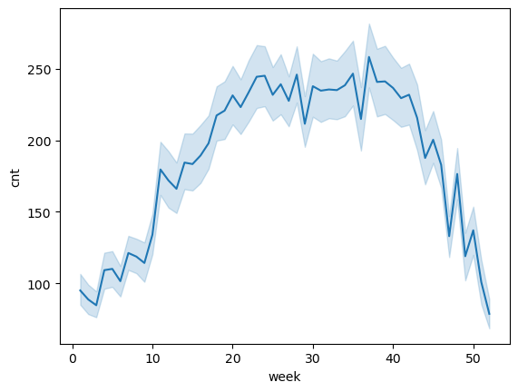

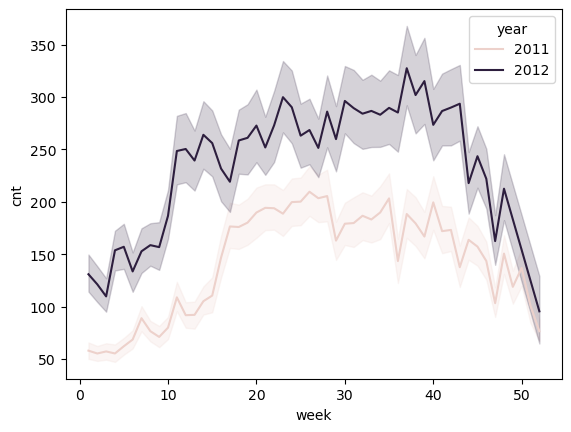

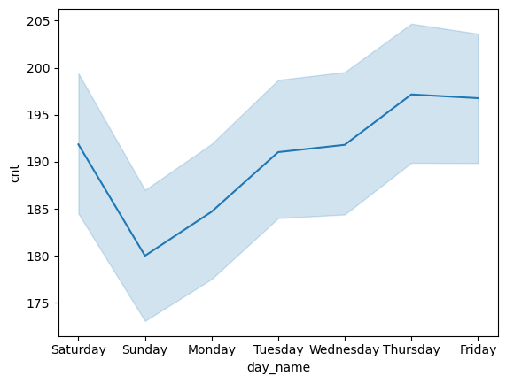

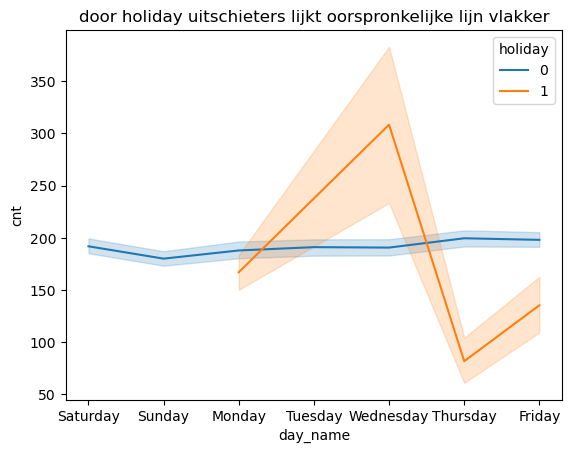

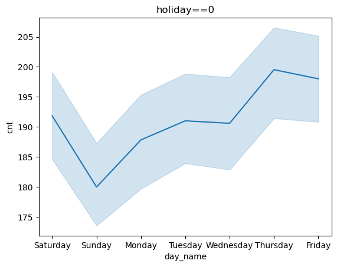

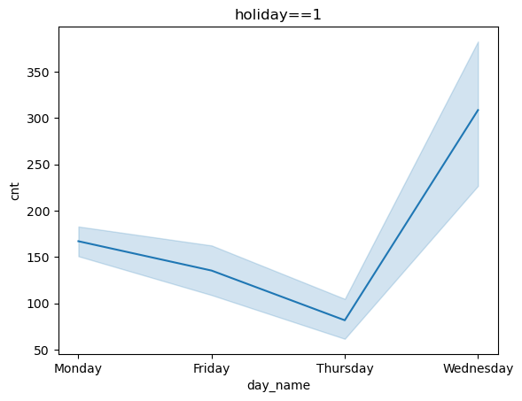

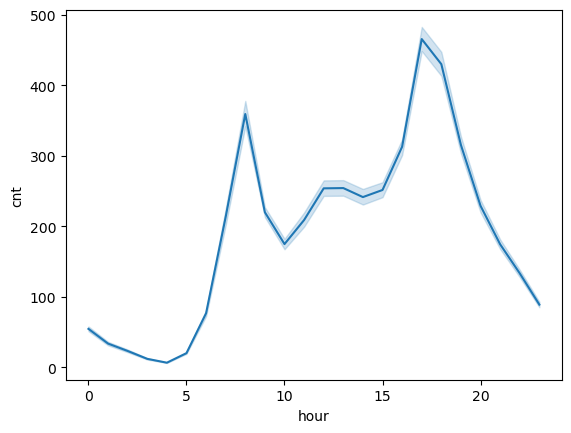

```python
sns.lineplot(data=df, x='week', y='cnt')
plt.show()
sns.lineplot(data=df, x='week', y='cnt', hue='year')
plt.show()
sns.lineplot(data=df, x='day_name', y='cnt')
plt.show()
sns.lineplot(data=df, x='day_name', y='cnt', hue="holiday")
plt.title('door holiday uitschieters lijkt oorspronkelijke lijn vlakker')
plt.show()
sns.lineplot(data=df[df['holiday']==0], x='day_name', y='cnt')
plt.title('holiday==0')
plt.show()
sns.lineplot(data=df[df['holiday']==1], x='day_name', y='cnt')
plt.title('holiday==1')
plt.show()
sns.lineplot(data=df, x='hour', y='cnt')
plt.show()

#2012 is hoger dan 2011
#lente / zomer meer vraag
#donderdag/vrijdag meeste vraag, zondag het minste
#pieken rond begin en einde werkdag
#holiday heeft wel invloed, maar heeft nader onderzoek nodig. Op woensdag in de vakantie is cnt veel hoger en op donderdagen juist lager. Kan met
#periode in het jaar te maken hebben.

#We vinden wel verbanden tussen tijdselementen en cnt, maar die zijn niet lineair. Lineair is als 1 omhoog gaat de ander ook omhoog gaat.
#Of 1 naar beneden en de ander omhoog.
#Dus niet geschikt voor correlatie. Als er een lineaire relatie is / lijkt te zijn dan is correlatie een goede maatstaf.
```